# PISA 2012

## by Lukas Jakson

**Table of Contents**

- 1. Introduction
- 2. Structure of PISA2012 dataset
- 3. Questions
- 4. Data Wrangling
- 5. Univariate Exploration
- 6. Bivariate Exploration
- 7. Multivariate Exploration
- 8. Conclusion

## 1. Introduction to PISA

**What Is PISA?**

The Program for International Student Assessment (PISA) is a system of international assessments that allows countries to compare outcomes of learning as students near the end of compulsory schooling. PISA core assessments measure the performance of 15-year-old students in mathematics, science, and reading literacy every 3 years. Coordinated by the Organization for Economic Cooperation and Development (OECD), PISA was first implemented in 2000 in 32 countries. It has since grown to 65 education systems in 2012.

**What PISA Measures**

PISA’s goal is to assess students’ preparation for the challenges of life as young adults. PISA assesses the application of knowledge in mathematics, science, and reading literacy to problems within a reallife context (OECD 1999). PISA does not focus explicitly on curricular outcomes and uses the term “literacy” in each subject area to indicate its broad focus on the application of knowledge and skills. For example, when assessing mathematics, PISA examines how well 15-year-old students can understand, use, and reflect on mathematics for a variety of real-life problems and settings that they may not encounter in the classroom. Scores on the PISA scales represent skill levels along a continuum of literacy skills. Each PISA data collection cycle assesses one of the three core subject areas in depth (considered the major subject area), although all three core subjects are assessed in each cycle (the other two subjects are considered minor subject areas for that assessment year). Assessing all three subjects every 3 years allows countries to have a consistent source of achievement data in each of the three subjects, while rotating one area as the primary focus over the years. Mathematics was the major subject area in 2012, as it was in 2003, since each subject is a major subject area once every three cycles. In 2012, mathematics, science, and reading literacy were assessed primarily through a paper-and-pencil assessment, and problem solving was administered via a computer-based assessment. In addition to these core assessments, education systems could participate in optional paper-based financial literacy and computer-based mathematics and reading assessments. The United States participated in these optional assessments. Visit www.nces.ed.gov/surveys/pisa for more information on the PISA assessments, including information on how the assessments were designed and examples of PISA questions.

Source: https://nces.ed.gov/pubs2014/2014024rev.pdf

## 2. Structure of PISA2012 dataset

The original data set contains 485.490 students and 636 features. In order to identify the features that are interesting for us, we will begin to wrangle our data first.

```python
# import all packages and set plots to be embedded inline
import numpy as np
import pandas as pd
import matplotlib.pyplot as plt
import seaborn as sns

%matplotlib inline
plt.style.use('seaborn-darkgrid')
```

```python
sns.set()
```

```python
pd.set_option('display.max_rows', 636)
pd.set_option('display.max_columns', 636)
```

```python
df = pd.read_csv('pisa2012.csv', encoding='latin-1', low_memory = False)
```

```python
df.head(3)
```

|  | Unnamed: 0 | CNT | SUBNATIO | STRATUM | OECD | NC | SCHOOLID | STIDSTD | ST01Q01 | ST02Q01 | ST03Q01 | ST03Q02 | ST04Q01 | ST05Q01 | ST06Q01 | ST07Q01 | ST07Q02 | ST07Q03 | ST08Q01 | ST09Q01 | ST115Q01 | ST11Q01 | ST11Q02 | ST11Q03 | ST11Q04 | ST11Q05 | ST11Q06 | ST13Q01 | ST14Q01 | … |
| --- | --- | --- | --- | --- | --- | --- | --- | --- | --- | --- | --- | --- | --- | --- | --- | --- | --- | --- | --- | --- | --- | --- | --- | --- | --- | --- | --- | --- | --- | --- |
| 0 | 1 | Albania | 80000 | ALB0006 | Non-OECD | Albania | 1 | 1 | 10 | 1.0 | 2 | 1996 | Female | No | 6.0 | No, never | No, never | No, never | None | None | 1.0 | Yes | Yes | Yes | Yes | NaN | NaN | <ISCED level 3A> | No | … |
| 1 | 2 | Albania | 80000 | ALB0006 | Non-OECD | Albania | 1 | 2 | 10 | 1.0 | 2 | 1996 | Female | Yes, for more than one year | 7.0 | No, never | No, never | No, never | One or two times | None | 1.0 | Yes | Yes | NaN | Yes | NaN | NaN | <ISCED level 3A> | Yes | … |
| 2 | 3 | Albania | 80000 | ALB0006 | Non-OECD | Albania | 1 | 3 | 9 | 1.0 | 9 | 1996 | Female | Yes, for more than one year | 6.0 | No, never | No, never | No, never | None | None | 1.0 | Yes | Yes | No | Yes | No | No | <ISCED level 3B, 3C> | Yes | … |

```python
df.isna().sum()
```

```
Unnamed: 0          0
CNT                 0
SUBNATIO            0
STRATUM             0
OECD                0
NC                  0
SCHOOLID            0
STIDSTD             0
ST01Q01             0
ST02Q01            52
ST03Q01             0
ST03Q02             0
ST04Q01             0
ST05Q01          9324
ST06Q01         27496
ST07Q01         48800
ST07Q02         54212
ST07Q03        179803
ST08Q01          6347
ST09Q01          6359
ST115Q01         6221
ST11Q01         24931
ST11Q02         44454
ST11Q03         85414
ST11Q04         94722
ST11Q05        137310
ST11Q06        147852
ST13Q01         27511
ST14Q01         95009
ST14Q02         77849
ST14Q03        103049
ST14Q04        181275
ST15Q01         17739
ST17Q01         42229
ST18Q01        114075
ST18Q02         97694
ST18Q03        122656
ST18Q04        193397
ST19Q01         34080
ST20Q01          9127
```

[output cut: 582 more lines]

```
W_FSTR71            0
W_FSTR72            0
W_FSTR73            0
W_FSTR74            0
W_FSTR75            0
W_FSTR76            0
W_FSTR77            0
W_FSTR78            0
W_FSTR79            0
W_FSTR80            0
WVARSTRR            0
VAR_UNIT            0
SENWGT_STU          0
VER_STU             0
dtype: int64
```

```python
df.shape
```

```
(485490, 636)
```

## 3. Questions

We have a data set with 485490 entries and 636 variables. Therefore I looked in the dictionary to better understand the meaning of the variables.

In the course of this, we found variables that will help us take a closer look at the following interesting features.

### 1. How do students compare globally in literacy performance in math, science, reading and overall?

To do this, we will review the average global and country-specific distribution of mathematics, reading, and science literacy skills.

### 2. Is there a difference in gender in terms of points scored?

We will take a look how girls performed compared to boys

### 3. Are there countries where students perform particularly well (99th percentile)?

We examine the countries from which students with particularly high literacy skills in math, science, and reading come. To do this, we will look at the distribution of particularly high scores (99th percentile) in math, reading, and science grouped by country.

### 4. Does a migration background have an effect on the points scored?

It is very interesting to ask what differences in scores there are between migrant children (first and second generation) and children whose parents are natives. We will look at classic immigration countries and compare them with Germany.

## 4. Wrangling

We will keep variables that we have previously identified as helpful for our analysis using the Dictonary.

```python
df = df[['CNT', 'ST03Q02', 'ST04Q01', 'AGE', 'PV1MATH', 'PV2MATH', 'PV3MATH', 'PV4MATH', 'PV5MATH', 'PV1READ', 'PV2READ',
         'PV3READ', 'PV4READ', 'PV5READ','PV1SCIE', 'PV2SCIE', 'PV3SCIE', 'PV4SCIE', 'PV5SCIE', 'COBN_F', 'COBN_M', 'COBN_S', 'IMMIG']]
```

```python
df.head()
```

|  | CNT | ST03Q02 | ST04Q01 | AGE | PV1MATH | PV2MATH | PV3MATH | PV4MATH | PV5MATH | PV1READ | PV2READ | PV3READ | PV4READ | PV5READ | PV1SCIE | PV2SCIE | PV3SCIE | PV4SCIE | PV5SCIE | COBN_F | COBN_M | COBN_S | IMMIG |
| --- | --- | --- | --- | --- | --- | --- | --- | --- | --- | --- | --- | --- | --- | --- | --- | --- | --- | --- | --- | --- | --- | --- | --- |
| 0 | Albania | 1996 | Female | 16.17 | 406.8469 | 376.4683 | 344.5319 | 321.1637 | 381.9209 | 249.5762 | 254.3420 | 406.8496 | 175.7053 | 218.5981 | 341.7009 | 408.8400 | 348.2283 | 367.8105 | 392.9877 | Albania | Albania | Albania | Native |
| 1 | Albania | 1996 | Female | 16.17 | 486.1427 | 464.3325 | 453.4273 | 472.9008 | 476.0165 | 406.2936 | 349.8975 | 400.7334 | 369.7553 | 396.7618 | 548.9929 | 471.5964 | 471.5964 | 443.6218 | 454.8116 | Albania | Albania | Albania | Native |
| 2 | Albania | 1996 | Female | 15.58 | 533.2684 | 481.0796 | 489.6479 | 490.4269 | 533.2684 | 401.2100 | 404.3872 | 387.7067 | 431.3938 | 401.2100 | 499.6643 | 428.7952 | 492.2044 | 512.7191 | 499.6643 | Albania | Albania | Albania | Native |
| 3 | Albania | 1996 | Female | 15.67 | 412.2215 | 498.6836 | 415.3373 | 466.7472 | 454.2842 | 547.3630 | 481.4353 | 461.5776 | 425.0393 | 471.9036 | 438.6796 | 481.5740 | 448.9370 | 474.1141 | 426.5573 | Albania | Albania | Albania | Native |
| 4 | Albania | 1996 | Female | 15.50 | 381.9209 | 328.1742 | 403.7311 | 418.5309 | 395.1628 | 311.7707 | 141.7883 | 293.5015 | 272.8495 | 260.1405 | 361.5628 | 275.7740 | 372.7527 | 403.5248 | 422.1746 | Albania | Albania | Albania | Native |

```python
df.isna().sum()
```

```
CNT            0
ST03Q02        0
ST04Q01        0
AGE          116
PV1MATH        0
PV2MATH        0
PV3MATH        0
PV4MATH        0
PV5MATH        0
PV1READ        0
PV2READ        0
PV3READ        0
PV4READ        0
PV5READ        0
PV1SCIE        0
PV2SCIE        0
PV3SCIE        0
PV4SCIE        0
PV5SCIE        0
COBN_F      3665
COBN_M      3647
COBN_S      3654
IMMIG      13697
dtype: int64
```

Now we have to replace the NaN values of the students age in the dataset with the mean age

```python
df.loc[np.isfinite(df['AGE']) == False, 'AGE'] = df['AGE'].mean()
```

```python
df.AGE.isna().sum()
```

```
0
```

In the next step we have to compute the average of the scores of a student in a particular discipline (Math, Science, Reading)

```python
# PV1MATH, PV2MATH, PV3MATH, PV4MATH, PV5MATH
df["math_score"] = (df["PV1MATH"] + df["PV2MATH"] + df["PV3MATH"] + df["PV4MATH"] + df["PV5MATH"]) / 5
```

```python
# PV1READ, PV2READ, PV3READ, PV4READ, PV5READ
```

```python
df["reading_score"] = (df["PV1READ"] + df["PV2READ"] + df["PV3READ"] + df["PV4READ"] + df["PV5READ"]) / 5
```

```python
# PV1SCIE, PV2SCIE, PV3SCIE, PV4SCIE, PV5SCIE
df["science_score"] = (df["PV1SCIE"] + df["PV2SCIE"] + df["PV3SCIE"] + df["PV4SCIE"] + df["PV5SCIE"]) / 5
```

```python
# Mean score in the three disciplines
df["overall_score"] = (df["math_score"] + df["reading_score"] + df["science_score"]) / 3
```

```python
df.head()
```

|  | CNT | ST03Q02 | ST04Q01 | AGE | PV1MATH | PV2MATH | PV3MATH | PV4MATH | PV5MATH | PV1READ | PV2READ | PV3READ | PV4READ | PV5READ | PV1SCIE | PV2SCIE | PV3SCIE | PV4SCIE | PV5SCIE | COBN_F | COBN_M | COBN_S | IMMIG | math_score | reading_score | science_score | overall_score |
| --- | --- | --- | --- | --- | --- | --- | --- | --- | --- | --- | --- | --- | --- | --- | --- | --- | --- | --- | --- | --- | --- | --- | --- | --- | --- | --- | --- |
| 0 | Albania | 1996 | Female | 16.17 | 406.8469 | 376.4683 | 344.5319 | 321.1637 | 381.9209 | 249.5762 | 254.3420 | 406.8496 | 175.7053 | 218.5981 | 341.7009 | 408.8400 | 348.2283 | 367.8105 | 392.9877 | Albania | Albania | Albania | Native | 366.18634 | 261.01424 | 371.91348 | 333.038020 |
| 1 | Albania | 1996 | Female | 16.17 | 486.1427 | 464.3325 | 453.4273 | 472.9008 | 476.0165 | 406.2936 | 349.8975 | 400.7334 | 369.7553 | 396.7618 | 548.9929 | 471.5964 | 471.5964 | 443.6218 | 454.8116 | Albania | Albania | Albania | Native | 470.56396 | 384.68832 | 478.12382 | 444.458700 |
| 2 | Albania | 1996 | Female | 15.58 | 533.2684 | 481.0796 | 489.6479 | 490.4269 | 533.2684 | 401.2100 | 404.3872 | 387.7067 | 431.3938 | 401.2100 | 499.6643 | 428.7952 | 492.2044 | 512.7191 | 499.6643 | Albania | Albania | Albania | Native | 505.53824 | 405.18154 | 486.60946 | 465.776413 |
| 3 | Albania | 1996 | Female | 15.67 | 412.2215 | 498.6836 | 415.3373 | 466.7472 | 454.2842 | 547.3630 | 481.4353 | 461.5776 | 425.0393 | 471.9036 | 438.6796 | 481.5740 | 448.9370 | 474.1141 | 426.5573 | Albania | Albania | Albania | Native | 449.45476 | 477.46376 | 453.97240 | 460.296973 |
| 4 | Albania | 1996 | Female | 15.50 | 381.9209 | 328.1742 | 403.7311 | 418.5309 | 395.1628 | 311.7707 | 141.7883 | 293.5015 | 272.8495 | 260.1405 | 361.5628 | 275.7740 | 372.7527 | 403.5248 | 422.1746 | Albania | Albania | Albania | Native | 385.50398 | 256.01010 | 367.15778 | 336.223953 |

We can drop the not necessary columns now.

```python
df.drop(columns = ['PV1MATH', 'PV2MATH', 'PV3MATH', 'PV4MATH', 'PV5MATH', 'PV1READ', 'PV2READ', 'PV3READ', 'PV4READ',
                   'PV5READ','PV1SCIE', 'PV2SCIE', 'PV3SCIE', 'PV4SCIE', 'PV5SCIE'], inplace = True)
```

```python
df.head()
```

|  | CNT | ST03Q02 | ST04Q01 | AGE | COBN_F | COBN_M | COBN_S | IMMIG | math_score | reading_score | science_score | overall_score |
| --- | --- | --- | --- | --- | --- | --- | --- | --- | --- | --- | --- | --- |
| 0 | Albania | 1996 | Female | 16.17 | Albania | Albania | Albania | Native | 366.18634 | 261.01424 | 371.91348 | 333.038020 |
| 1 | Albania | 1996 | Female | 16.17 | Albania | Albania | Albania | Native | 470.56396 | 384.68832 | 478.12382 | 444.458700 |
| 2 | Albania | 1996 | Female | 15.58 | Albania | Albania | Albania | Native | 505.53824 | 405.18154 | 486.60946 | 465.776413 |
| 3 | Albania | 1996 | Female | 15.67 | Albania | Albania | Albania | Native | 449.45476 | 477.46376 | 453.97240 | 460.296973 |
| 4 | Albania | 1996 | Female | 15.50 | Albania | Albania | Albania | Native | 385.50398 | 256.01010 | 367.15778 | 336.223953 |

In the next step we will change the column names the make them more clear using the dictionary which was provided.

```python
df.rename({'CNT' : 'country', 'ST03Q02' : 'year_of_birth', 'ST04Q01' : 'gender', 'AGE' : 'age', 'COBN_F' : 'birth_country_father',
           'COBN_M' : 'birth_country_mother', 'COBN_S' : 'birth_country_child', 'IMMIG' : 'immigration_status'}, axis = 'columns', inplace = True)
```

```python
df.sample(3)
```

|  | country | year_of_birth | gender | age | birth_country_father | birth_country_mother | birth_country_child | immigration_status | math_score | reading_score | science_score | overall_score |
| --- | --- | --- | --- | --- | --- | --- | --- | --- | --- | --- | --- | --- |
| 172119 | Estonia | 1996 | Male | 15.83 | Estonia | Estonia | Estonia | Native | 494.71104 | 511.70290 | 525.49420 | 510.636047 |
| 85184 | Canada | 1996 | Female | 15.33 | Canada | Canada | Canada | Native | 529.37374 | 579.77090 | 559.06378 | 556.069473 |
| 66547 | Brazil | 1996 | Female | 16.17 | Brazil | Brazil | Brazil | Native | 309.63546 | 356.72862 | 344.31182 | 336.891967 |

```python
df.country.unique()
```

```
array(['Albania', 'United Arab Emirates', 'Argentina', 'Australia',
       'Austria', 'Belgium', 'Bulgaria', 'Brazil', 'Canada',
       'Switzerland', 'Chile', 'Colombia', 'Costa Rica', 'Czech Republic',
       'Germany', 'Denmark', 'Spain', 'Estonia', 'Finland', 'France',
       'United Kingdom', 'Greece', 'Hong Kong-China', 'Croatia',
       'Hungary', 'Indonesia', 'Ireland', 'Iceland', 'Israel', 'Italy',
       'Jordan', 'Japan', 'Kazakhstan', 'Korea', 'Liechtenstein',
       'Lithuania', 'Luxembourg', 'Latvia', 'Macao-China', 'Mexico',
       'Montenegro', 'Malaysia', 'Netherlands', 'Norway', 'New Zealand',
       'Peru', 'Poland', 'Portugal', 'Qatar', 'China-Shanghai',
       'Perm(Russian Federation)', 'Florida (USA)', 'Connecticut (USA)',
       'Massachusetts (USA)', 'Romania', 'Russian Federation',
       'Singapore', 'Serbia', 'Slovak Republic', 'Slovenia', 'Sweden',
       'Chinese Taipei', 'Thailand', 'Tunisia', 'Turkey', 'Uruguay',
       'United States of America', 'Vietnam'], dtype=object)
```

```python
# Adding the three us-american states to United States of America
for x in ["Florida (USA)", "Connecticut (USA)", "Massachusetts (USA)"]:
    df["country"].replace(x, "United States of America", inplace = True)
```

```python
# Renaming countries
df["country"].replace("Chinese Taipei", "Taiwan", inplace = True)
df["country"].replace("Hong Kong-China", "Honk Kong", inplace = True)
df["country"].replace("Macao-China", "Macao", inplace = True)
df["country"].replace("China-Shanghai", "People's Republic of China", inplace = True)
```

```python
# Adding Perm to Russian Federation
df["country"].replace("Perm(Russian Federation)", "Russian Federation", inplace = True)
```

```python
df["country"].unique()
```

```
array(['Albania', 'United Arab Emirates', 'Argentina', 'Australia',
       'Austria', 'Belgium', 'Bulgaria', 'Brazil', 'Canada',
       'Switzerland', 'Chile', 'Colombia', 'Costa Rica', 'Czech Republic',
       'Germany', 'Denmark', 'Spain', 'Estonia', 'Finland', 'France',
       'United Kingdom', 'Greece', 'Honk Kong', 'Croatia', 'Hungary',
       'Indonesia', 'Ireland', 'Iceland', 'Israel', 'Italy', 'Jordan',
       'Japan', 'Kazakhstan', 'Korea', 'Liechtenstein', 'Lithuania',
       'Luxembourg', 'Latvia', 'Macao', 'Mexico', 'Montenegro',
       'Malaysia', 'Netherlands', 'Norway', 'New Zealand', 'Peru',
       'Poland', 'Portugal', 'Qatar', "People's Republic of China",
       'Russian Federation', 'United States of America', 'Romania',
       'Singapore', 'Serbia', 'Slovak Republic', 'Slovenia', 'Sweden',
       'Taiwan', 'Thailand', 'Tunisia', 'Turkey', 'Uruguay', 'Vietnam'],
      dtype=object)
```

## 5. Univariate Exploration

*In this section, we will investigate the distributions of individual variables.*

### 5. 1. Distribution of Scores

First, we look at the distribution of PISA scores in math, reading, science, and the previously calculated overall score. We will consider all values above the 99th percentile as particularly high values, which we will look at in more detail afterwards.

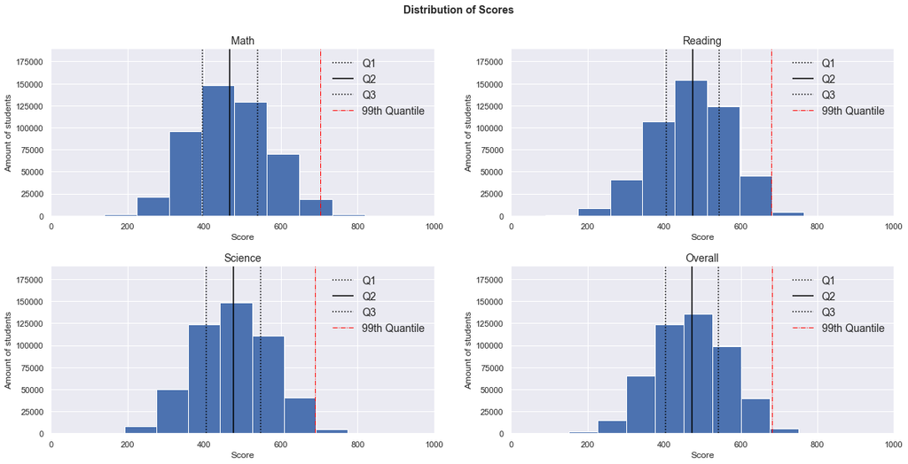

```python
# Creating Plots
plt.figure(figsize = [20, 20])
plt.subplots_adjust(hspace = 0.3)

scores = ["math_score", "reading_score", "science_score", "overall_score"]

plt.hist(df["math_score"])

for i in range(len(scores)):
    plt.subplot(len(scores), 2, i +1)
    plt.hist(df[scores[i]])
    plt.xlim(0, 1000)
    plt.ylim(0, 190000)
    plt.vlines(np.quantile(df[scores[i]], 0.25), 0, 190000, color = "black", linestyle = "dotted", lw = 1.5, label = "Q1")
    plt.vlines(np.quantile(df[scores[i]], 0.5), 0, 190000, color = "black", linestyle = "solid", lw = 1.5, label = "Q2")
    plt.vlines(np.quantile(df[scores[i]], 0.75), 0, 190000, color = "black", linestyle = "dotted", lw = 1.5, label = "Q3")
    plt.vlines(np.quantile(df[scores[i]], 0.99), 0, 190000, color = "red",  linestyle = "-.", lw = 1, label = "99th Quantile")
    plt.legend(loc = "upper right", prop={'size': 14})
    plt.xlabel("Score");
    plt.ylabel("Amount of students")
    plt.title(scores[i].split("_")[0].title(), fontsize = 14)

plt.suptitle("Distribution of Scores", y = 0.92, ha = "center", weight = "bold", fontsize = 14)
```

**Observations**

- The scores are distributed in a clear, smooth, unimodal distribution.
- In terms of the overall score, which combines all three disciplines (Math, Reading, Science) the majority of students score between about 400 and 550.
- Therefore, it can also be assumed that the test was constructed in a balanced manner.

### 5. 2. Gender

Now let's see how gender was distributed.

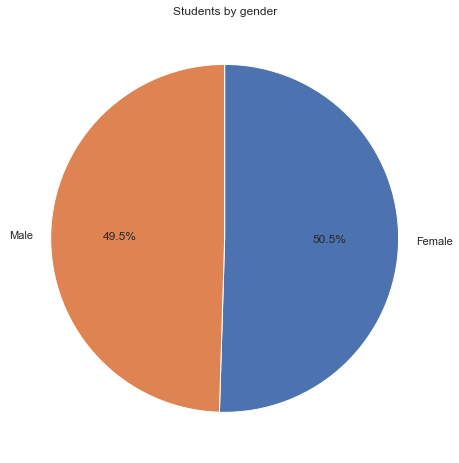

```python
# Creating plots
fig, ax = plt.subplots(figsize = (8, 8))
plt.pie(df['gender'].value_counts(), labels= df['gender'].value_counts().index, startangle = 90, counterclock = False, autopct='%1.1f%%')
plt.title('Students by gender')
```

**Observations:**

- Both groups are represented about half

In a moment, we will examine whether there is a difference in the distribution of points between girls and boys. But before that, we would like to see what the percentage of migrants who participated was.

### 5. 3. Immigration Status

Now let's look at how many migrants (first or second generation) participated in the tests compared to natives.

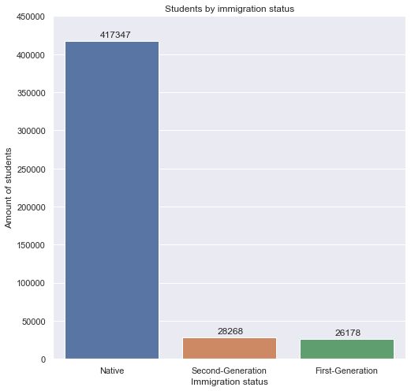

```python
# Creating plots
fig, ax = plt.subplots(figsize = (8,8))

sns.countplot(x = "immigration_status", data = df)

ax.set_ylim(0, 450000)
ax.set_title("Students by immigration status")
ax.set_ylabel("Amount of students")
ax.set_xlabel("Immigration status")

for patch in ax.patches:
    ax.annotate('{:.0f}'.format(patch.get_height()), (patch.get_x()+0.3, patch.get_height()+5000))
```

**Observations**

- Nearly one in eight students tested worldwide had an immigrant background in the country where they were tested.

Later, we would like to review how migrants to classic immigration countries such as the U.S., Canada, Australia, New Zealand, and Israel fared in comparison to Germany.

### 5. 4. Difference in gender

```python
# Creating queries for plots
df_75 = df.query("overall_score >= {}".format(np.quantile(df["overall_score"], 0.75)))
df_95 = df.query("overall_score >= {}".format(np.quantile(df["overall_score"], 0.95)))
df_99 = df.query("overall_score >= {}".format(np.quantile(df["overall_score"], 0.99)))
```

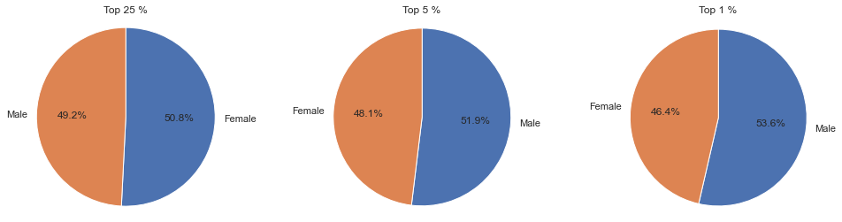

```python
# Creating plots
percentiles = [75, 95, 99]
fig, ax = plt.subplots(figsize = (16, 16))
plt.subplots_adjust(wspace = 0.5)

for i in range(len(percentiles)):
    plt.subplot(1, len(percentiles), i + 1)
    df_percentiles = eval('df_'+str(percentiles[i]))
    plt.pie(df_percentiles["gender"].value_counts(), labels = df_percentiles['gender'].value_counts().index, counterclock=False, startangle = 90, autopct='%1.1f%%')
    plt.axis("square")
    plt.title("Top " + str(100 - percentiles[i]) + " %")
```

**Observations**

- As the top nth percentile increases, so does the gender gap.

So we can answer **Question 2: Is there a difference in gender in terms of points scored?**

We can see that as the score increases, the proportion of girls decreases. We will discuss why this might be the case later in the conclusion. Because we found that there is a difference between Female and Male in the higher scores, we would like to check if there are differences between countries in the higher scores.

### 5. 5. Top 1 % students by country

Next, we are interested in which countries the students who are in the top 1% were in and limit that to the top 20 countries.

```python
# Top 1 % of students in each discipline by country
high_score_math = df.query("math_score > {}".format(np.quantile(df["math_score"], 0.99)))["country"].value_counts().nlargest(20)
high_score_science = df.query("science_score > {}".format(np.quantile(df["science_score"], 0.99)))["country"].value_counts().nlargest(20)
high_score_reading = df.query("reading_score > {}".format(np.quantile(df["reading_score"], 0.99)))["country"].value_counts().nlargest(20)
high_score_overall = df.query("overall_score > {}".format(np.quantile(df["overall_score"], 0.99)))["country"].value_counts().nlargest(20)
```

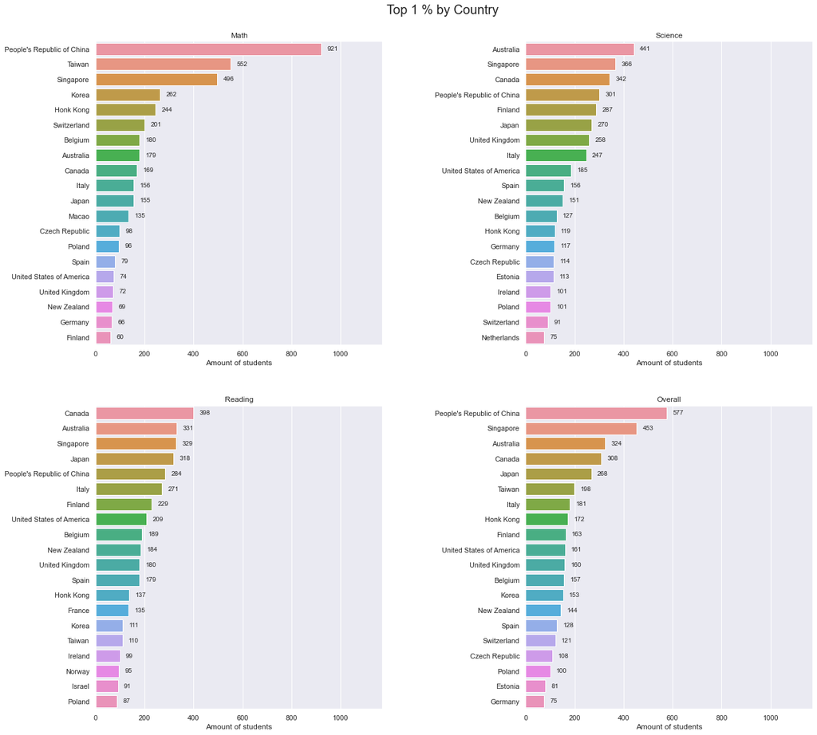

```python
plt.figure(figsize = [20, 40])
plt.subplots_adjust(hspace = 0.2, wspace = 0.5)

# Defining function for barplot
def create_barplot(xSrc):
    sns.barplot(x = xSrc.values, y = xSrc.index)
    indexes, labels = plt.yticks()
    for index, label in zip(indexes, labels):
        plt.text(y = index, x = xSrc[label.get_text()] + 25, s = xSrc[label.get_text()], va = 'center', fontsize = 10)
    plt.xlim(0, high_score_math.values[0]+250)
    plt.xlabel("Amount of students")

plt.subplot(4, 2, 1)
create_barplot(high_score_math)
plt.title("Math")


plt.subplot(4, 2, 2)
create_barplot(high_score_science)
plt.title("Science")

plt.subplot(4, 2, 3)
create_barplot(high_score_reading)
plt.title("Reading")

plt.subplot(4, 2, 4)
create_barplot(high_score_overall)
plt.title("Overall")

plt.suptitle("Top 1 % by Country", fontsize=20, y = 0.9)
```

**Observations:**

- Overall, Asian countries have many students who are in the top 1%. China in particular stands out in mathematics, leading on average in all three disciplines (Math, Science, Reading), ahead of Singapore and Australia.

Now we can answer **Question 3. Are there countries where students perform particularly well (99th percentile)?**

Yes, there are countries that have a very high percentage of exceptionally good students. Especially in mathematics, you see the dominance of Asian countries. As we found out earlier, the higher the score, the lower the proportion of girls. We discuss why this might be in conclusion.

## 6. Bivariate Exploration

In this section, we will investigate the relationships between pairs of relevant variables in our data.

### 6. 1. Top 10 Countries

Next, we would like to look at how the country of the students affects the points scored. Based on the fact that some countries produce very good students, we will look at whether these countries produce the better students overall, or whether this was just an aberration.

```python
# Creating queries
math_mean = df.groupby("country").math_score.mean().sort_values(ascending = False).nlargest(10)
science_mean = df.groupby("country").science_score.mean().sort_values(ascending = False).nlargest(10)
reading_mean = df.groupby("country").reading_score.mean().sort_values(ascending = False).nlargest(10)
overall_mean = df.groupby("country").overall_score.mean().sort_values(ascending = False).nlargest(10)

# Computing means
global_math_mean = round(df.math_score.mean())
global_science_mean = round(df.science_score.mean())
global_reading_mean = round(df.reading_score.mean())
global_overall_mean = round(df.overall_score.mean())
```

[figure not shown]

```python
# Creating plots
disc = [math_mean, science_mean, reading_mean, overall_mean]
global_means = [global_math_mean, global_science_mean, global_reading_mean, global_overall_mean]

fig, ax = plt.subplots(figsize = (20,28))
plt.subplots_adjust(hspace = 0.35)

for i in range(len(disc)):

    ax = plt.subplot(4, 1, i + 1)
    sns.barplot(y = disc[i].values, x = disc[i].index)
    ax.set_ylim(0, 800)

    plt.hlines(global_means[i], -0.5, 9.5, color='k', linestyle='--', label = "Global Mean: {}".format(global_means[i]))
    plt.xlabel("Country");
    plt.ylabel("Score")
    plt.legend(loc = "upper right")
    plt.title(scores[i].split("_")[0].title() + " Score", fontsize = 14, ha = "center")
    for patch in ax.patches:
        ax.annotate('{:.0f}'.format(patch.get_height()), (patch.get_x()+0.3, patch.get_height()+10))

plt.suptitle("Top 10 Countries by average score", y = 0.92, ha = "center", weight = "bold", fontsize = 14)
```

**Observations:**

### 6. 2. Score distribution by country

Next, we would like to take a closer look at the distribution of points in the three competencies (and the overall average) in each country in descending order.

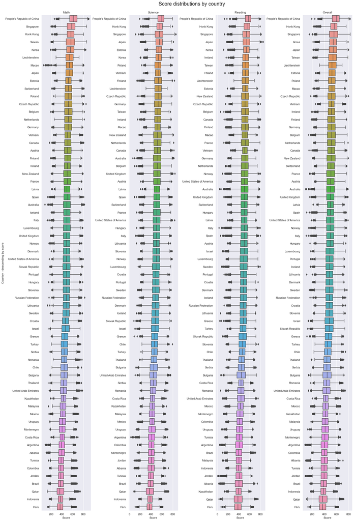

```python
# Creating plots
fig, ax = plt.subplots(figsize = (22,36))

plt.subplots_adjust(wspace = 0.75)

fig.suptitle("Score distributions by country", fontsize = 20, y = 0.9, ha = "center");

plt.subplot(1, 4, 1)
sns.boxplot(x = df["math_score"], y = df["country"], order = df.groupby("country")["math_score"].mean().sort_values(ascending = False).index)
plt.title("Math")
plt.ylabel("Country - descending by score")
plt.xlabel("Score")

plt.subplot(1, 4, 2)
sns.boxplot(x = df["science_score"], y = df["country"], order = df.groupby("country")["science_score"].mean().sort_values(ascending = False).index)
plt.title("Science")
plt.ylabel("")
plt.xlabel("Score")

plt.subplot(1, 4, 3)
sns.boxplot(x = df["reading_score"], y = df["country"], order = df.groupby("country")["reading_score"].mean().sort_values(ascending = False).index)
plt.title("Reading")
plt.ylabel("")
plt.xlabel("Score")

plt.subplot(1, 4, 4)
sns.boxplot(x = df["overall_score"], y = df["country"], order = df.groupby("country")["overall_score"].mean().sort_values(ascending = False).index)
plt.title("Overall")
plt.ylabel("")
plt.xlabel("Score")
```

**Observations**

- in most countries, the points obtained in the different three competencies are within +-10 ranks. The points achieved are close to each other in this respect
- As we noted earlier, Asian countries dominate in all disciplines.
- By looking at the outlier scores, we can see if they are still within the regular range (for a specific country). For example, we can see that Singapore, Taiwan and Hong Kong have few outlier scores in mathematics and we can assume that this speaks for a consistently high level of mathematics in the schools in these countries.

From this, we can make the assumption that students who do well in one subject will do similarly well in other subjects. To verify this, we will look for a correlation later on.

### 6. 3. Scores by Immigration Status

Now we would like to check whether a migration background has an influence on the points achieved in the respective competencies.

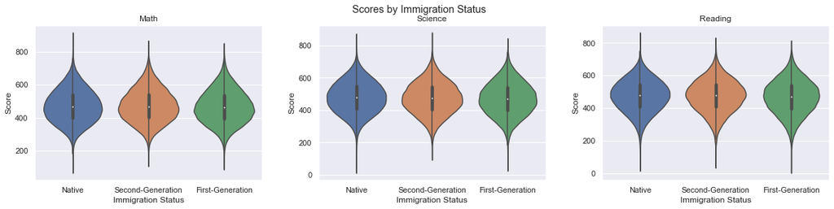

```python
fig, ax = plt.subplots(figsize = (20,4))
plt.subplots_adjust(wspace = 0.25)

plt.subplot(1, 3, 1)
sns.violinplot(y = "math_score", x = "immigration_status", data = df)
plt.xlabel("Immigration Status")
plt.ylabel("Score")
plt.title("Math")

plt.subplot(1, 3, 2)
sns.violinplot(y = "science_score", x = "immigration_status", data = df)
plt.xlabel("Immigration Status")
plt.ylabel("Score")
plt.title("Science")

plt.subplot(1, 3, 3)
sns.violinplot(y = "reading_score", x = "immigration_status", data = df)
plt.xlabel("Immigration Status")
plt.ylabel("Score")
plt.title("Reading")

plt.suptitle("Scores by Immigration Status")
```

**Observations:**

- Globally, there seems to be no difference in the distribution of points when considering immigration background.

To verify this, we will later compare classic immigration countries with Germany.

Now we can finally answer the **Question 1. How do students compare globally in literacy performance in math, science, reading and overall?**

Overall, the top ten countries include seven countries from Asia and three countries from Europe. The dominance of Asian countries is particularly evident in the subject of mathematics.

We will discuss why this might be the case later in the conclusion.

The majority of countries (about 80% ) perform similarly across the three subjects. We can therefore assume that students who do well in one subject also achieve similarly good results in the other subjects.

## 7. Multivariate Exploration

*In this section, we will investigate the relationships between the interactions of three or more variables at the same time.*

### 7. 1. Correlation between the three competencies

Previously, we have already seen that countries that are good in one discipline are also good in other disciplines. Now we want to see if there is indeed a correlation.

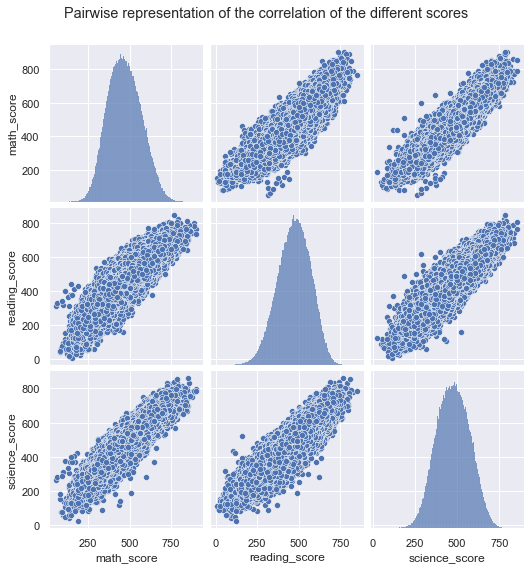

```python
# Creating pairplot
g = sns.pairplot(data = df, vars=["math_score", "reading_score", "science_score"])
g.fig.suptitle("Pairwise representation of the correlation of the different scores", y = 1.05)
```

Observations:

- there is a strong positive correlation between the three competencies

### 7. 2. Points scored and migration status in classic immigration countries compared with Germany

We now want to look at whether migration status has an effect on the points scored.

We will look at the classic immigration countries Australia, Israel, Canada, New Zealand and the USA and compare them with Germany.

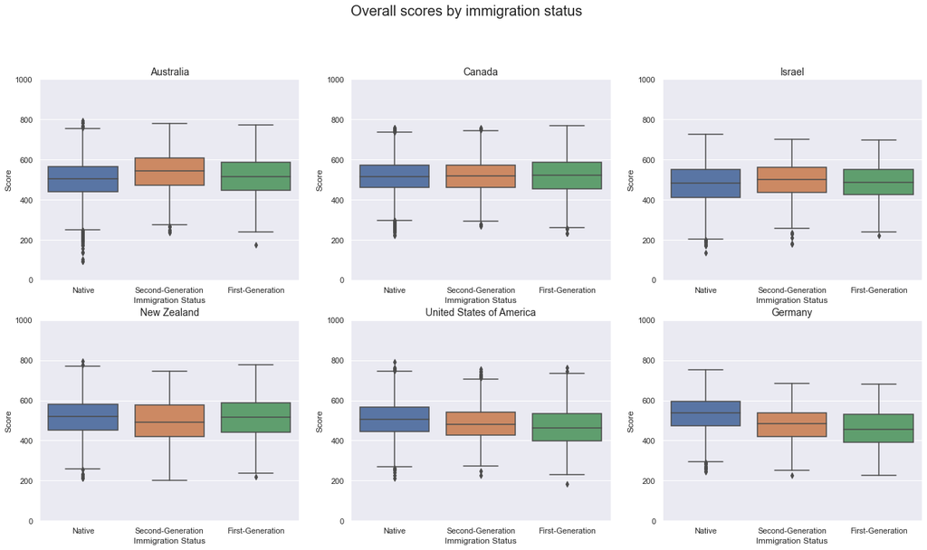

```python
# Creating plots

countries = ["Australia", "Canada", "Israel", "New Zealand", "United States of America", "Germany"]

fig, ax = plt.subplots(figsize = (22,36))
plt.subplots_adjust(hspace = 0.2)

for i in range(len(countries)):

    ax = plt.subplot(len(countries), 3, i + 1)
    ax.set_ylim(0, 1000)
    sns.boxplot(x = "immigration_status", y = "overall_score", data = df[df["country"] == countries[i]], order = ["Native", "Second-Generation", "First-Generation"])
    plt.title(countries[i], size = 14)
    plt.xlabel("Immigration Status");
    plt.ylabel("Score")

plt.suptitle("Overall scores by immigration status", fontsize = 20, y = 0.92)
```

**Observations:**

Now we look at whether there are differences in Germany in the individual competencies, or whether migrants perform worse than natives in all disciplines.

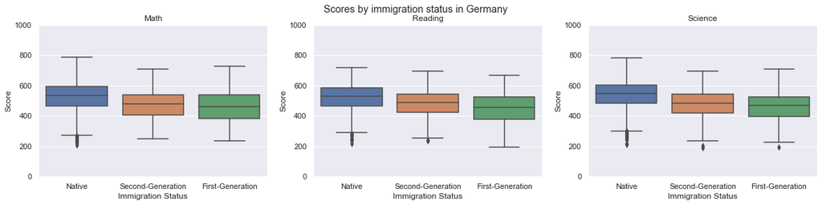

```python
# Creating plots
disc = ["math", "reading", "science"]

fig, ax = plt.subplots(figsize = (20,4))
plt.subplots_adjust(hspace = 1)

for i in range(len(disc)):
    ax = plt.subplot(1, len(disc), i+1)
    ax.set_ylim(0, 1000)
    sns.boxplot(x = "immigration_status", y = disc[i]+"_score", data = df[df["country"] == "Germany"], order = ["Native", "Second-Generation", "First-Generation"])
    plt.title(disc[i].split("_")[0].title())
    plt.xlabel("Immigration Status");
    plt.ylabel("Score")

plt.suptitle("Scores by immigration status in Germany")
```

**Observation**

The smallest differences seem to be in Reading, though it is clear that migrant children and children of migrants do significantly worse than natives in all areas.

## 7. 3. Differences in points scored in Germany depending on migrants' country of immigration

Most of the 21.2 million people in Germany with a migration background in 2019 were from Turkey (13.3 percent), followed by Poland (10.5 percent) and former Soviet Union (6.5 percent). Therefore, we would like to see if there are any differences between these three nationalities.

```python
df_ger = df[(df["country"] == "Germany") & (df["birth_country_father"] != "Missing")]
#df_ger
df_ger_pol = df_ger.query("birth_country_father == 'Poland '")
df_ger_tur = df_ger.query("birth_country_father == 'Turkey '")
df_ger_rus = df_ger.query("birth_country_father == 'One of the former USSR republics '")
```

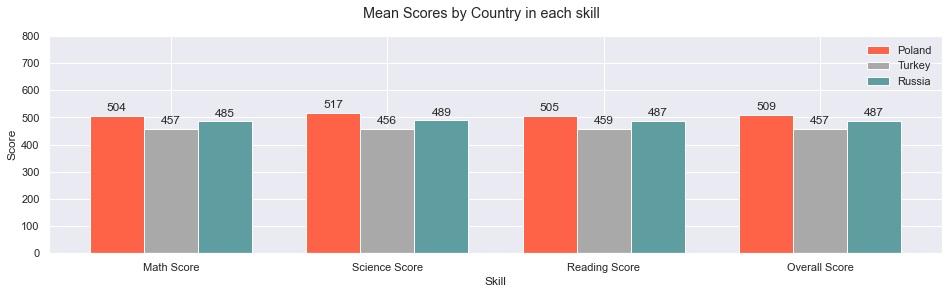

```python
# https://matplotlib.org/3.1.1/gallery/lines_bars_and_markers/barchart.html#sphx-glr-gallery-lines-bars-and-markers-barchart-py
fig, ax = plt.subplots(figsize = (16, 4))
labels = ["Math Score", "Science Score", "Reading Score", "Overall Score"]
width = 0.4

rects1 = ax.bar(0.4, round(df_ger_pol["math_score"].mean()), width, label='Poland', color = "tomato")
rects2 = ax.bar(0.8, round(df_ger_tur["math_score"].mean()), width, label='Turkey', color = "darkgrey")
rects3 = ax.bar(1.2, round(df_ger_rus["math_score"].mean()), width, label='Russia', color = "cadetblue")
rects4 = ax.bar(2, round(df_ger_pol["science_score"].mean()), width, color = "tomato")
rects5 = ax.bar(2.4, round(df_ger_tur["science_score"].mean()), width, color = "darkgrey")
rects6 = ax.bar(2.8, round(df_ger_rus["science_score"].mean()), width, color = "cadetblue")
rects7 = ax.bar(3.6, round(df_ger_pol["reading_score"].mean()), width, color = "tomato")
rects8 = ax.bar(4, round(df_ger_tur["reading_score"].mean()), width, color = "darkgrey")
rects9 = ax.bar(4.4, round(df_ger_rus["reading_score"].mean()), width, color = "cadetblue")
rects10 = ax.bar(5.2, round(df_ger_pol["overall_score"].mean()), width, color = "tomato")
rects11 = ax.bar(5.6, round(df_ger_tur["overall_score"].mean()), width, color = "darkgrey")
rects12 = ax.bar(6, round(df_ger_rus["overall_score"].mean()), width, color = "cadetblue")


ax.set_ylim(0,800)
ax.set_xticks([0.8, 2.4, 4, 5.6])
ax.set_xticklabels(labels)
ax.legend()

def autolabel(rects):
    """Attach a text label above each bar in *rects*, displaying its height."""
    for rect in rects:
        height = rect.get_height()
        ax.annotate('{}'.format(height),
                    xy=(rect.get_x() + rect.get_width() / 2, height),
                    xytext=(0, 3),  # 3 points vertical offset
                    textcoords="offset points",
                    ha='center', va='bottom')


autolabel(rects1)
autolabel(rects2)
autolabel(rects3)
autolabel(rects4)
autolabel(rects5)
autolabel(rects6)
autolabel(rects7)
autolabel(rects8)
autolabel(rects9)
autolabel(rects10)
autolabel(rects11)
autolabel(rects12)

plt.suptitle("Mean Scores by Country in each skill")
plt.ylabel("Score")
plt.xlabel("Skill")
```

**Observation**

The samples are probably too small to draw conclusions, however, Polish-born students seem to do better than those of Russian and Turkish origin.

## 7.4 Differences of migrants of Turkish origin in the scores achieved in the PISA study in Germany depending on gender.

In recent years, there have been frequent reports in the German media that students of Turkish origin are among the weakest at school. There have also been reports that girls of Turkish origin, if allowed by their parents, have caught up in school performance and overtaken male students of Turkish origin.

```python
# Turkish Male / Female
df_ger_tur.query("gender == 'Male'")["gender"].value_counts()[0], df_ger_tur.query("gender == 'Female'")["gender"].value_counts()[0]
```

```
(110, 96)
```

```python
df_ger_tur.query("gender == 'Male'")["overall_score"].mean(), df_ger_tur.query("gender == 'Female'")["overall_score"].mean()
```

```
(451.0766212121213, 464.1890803472222)
```

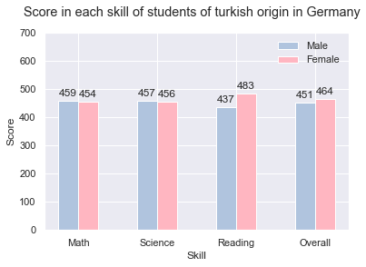

```python
fig, ax = plt.subplots()

labels = ["Math", "Science", "Reading", "Overall"]
width = 0.25

rects1 = ax.bar(1, round(df_ger_tur.query("gender == 'Male'")["math_score"].mean()), width, label='Male', color = "lightsteelblue")
rects2 = ax.bar(1.25, round(df_ger_tur.query("gender == 'Female'")["math_score"].mean()), width, label='Female', color = "lightpink")
rects3 = ax.bar(2, round(df_ger_tur.query("gender == 'Male'")["science_score"].mean()), width, color = "lightsteelblue")
rects4 = ax.bar(2.25, round(df_ger_tur.query("gender == 'Female'")["science_score"].mean()), width, color = "lightpink")
rects5 = ax.bar(3, round(df_ger_tur.query("gender == 'Male'")["reading_score"].mean()), width,  color = "lightsteelblue")
rects6 = ax.bar(3.25, round(df_ger_tur.query("gender == 'Female'")["reading_score"].mean()), width, color = "lightpink")
rects7 = ax.bar(4, round(df_ger_tur.query("gender == 'Male'")["overall_score"].mean()), width,  color = "lightsteelblue")
rects8 = ax.bar(4.25, round(df_ger_tur.query("gender == 'Female'")["overall_score"].mean()), width, color = "lightpink")



ax.set_ylim(0,700)
ax.set_xticks([1.125, 2.125, 3.125, 4.125])
ax.set_xticklabels(labels)

ax.legend()

def autolabel(rects):
    """Attach a text label above each bar in *rects*, displaying its height."""
    for rect in rects:
        height = rect.get_height()
        ax.annotate('{}'.format(height),
                    xy=(rect.get_x() + rect.get_width() / 2, height),
                    xytext=(0, 3),  # 3 points vertical offset
                    textcoords="offset points",
                    ha='center', va='bottom')


autolabel(rects1)
autolabel(rects2)
autolabel(rects3)
autolabel(rects4)
autolabel(rects5)
autolabel(rects6)
autolabel(rects7)
autolabel(rects8)
plt.xlabel("Skill")
plt.ylabel("Score")
plt.suptitle("Score in each skill of students of turkish origin in Germany")
```

**Observation**

Again, the sample is too small to draw a meaningful conclusion. However, one can see that there is something to the media reports. Especially in reading, girls of Turkish origin are better than boys - on average 10.5 %.

## 8. Conclusion, Answers and Discussion

**Q: Are there countries where students perform particularly well (99th percentile)?**

The top 1% of students were mainly from Asian countries such as China, Singapore, Hong Kong, Taiwan and Korea. Asian countries dominated in mathematics in particular. China was the top performer here.

**Q: How do students compare globally in literacy performance in math, science, reading and overall?**

The scores are distributed in a clear, smooth, unimodal distribution, where the majority of student score between 400 and 550 points.

The mean scores showed a similar picture in all three competencies. In math, China scored 611 points, 30% above the global average of 470. China also led in reading and science, although not as strongly as in math. Seven of the top 10 countries were Asian. Three of the countries were from Europe: Poland, Estonia and Liechtenstein.

I suspect that China's dominance is due to the Chinese education system, which "propagates education through 'chiku'" ('chiku' means suffering). Children there quickly learn that education does not depend on their talent but on their effort. This also explains the particularly good performance of students from socially disadvantaged backgrounds there.

In most countries, students perform equally well in all three competencies. In about 80 % of the countries, the scores achieved in the three competencies are very close to each other. When looking at individual scores, it is noticeable that Singapore, Hong Kong and Taiwan have few outliers in the higher scores, which indicates a consistently high level in mathematics.

We could also see that there is a strong, positive correlation between the three subjects. This suggests that students are performing similarly in all disciplines.

**Q: Is there a difference in gender in terms of points scored?**

Males and females are almost equally distributed. However, the proportion of female students decreases the higher the values are. From the 95th percentile, the decrease is clear.

I suspect it is because there are many Asian countries represented in the top scores. In China, the ratio of boys to girls in 2015 was 115.2 to 100, which could be a possible explanation.

However, as we have also seen, there are slight differences among migrants of Turkish origin living in Germany. There, the girls seem to be somewhat better.

**Q: Does a migration background have an effect on the points scored?**

One in eight of the students tested had a migrant background, meaning they were either first- or second-generation migrants.

As we could see, migrants in classic immigration countries such as the U.S., Canada, New Zealand, Israel and Australia perform better than in Germany, which I chose because I live here.

In Germany, there is a big difference between migrants and natives. First-generation migrants do worse than second-generation migrants.

We looked at whether there are differences among migrants in Germany in the three subjects. However, these are minimal.

Since the classic immigration countries mentioned above have stringent immigration rules, i.e., immigrants must have an education, must speak the language, and usually must also have a job, we can assume that in these countries students participated whose parents have high qualifications and speak the language.

In Germany, migration status, especially in the first generation, often means that neither the parents nor the children speak the language, professional qualifications are not available, and parents are often employed in precarious jobs.